# Lab11

Claire

2019年5月20日

### 空間分析 Lab 11

#### 地理二 b06208028 甘佳昀

# 1.

```r
rm(list = ls())
library(spdep)
library(rgdal)
library(ggplot2)
library(GISTools)
TWPOP <- readOGR(dsn = '.', layer = "Popn_TWN2", encoding="utf8")

TWTable<-TWPOP@data
```

## Moran’s I coefficient

```r
TWN_nb<-poly2nb(TWPOP) #QUEEN = TRUE，紀錄每個polygon的鄰居數
TWN_nb_w<- nb2listw(TWN_nb, zero.policy=T) # default: style = "W" #列標準化
density<-(TWTable$A0A14_CNT+TWTable$A15A64_CNT+TWTable$A65UP_CNT)/poly.areas(TWPOP)
density<-as.numeric(paste(density))
M<-moran.test(density, listw=TWN_nb_w, zero.policy=T); M  #人口密度資料，listw:空間權重，zero:如果有孤立點的話怎麼半
```

```
##
##  Moran I test under randomisation
##
## data:  density
## weights: TWN_nb_w  n reduced by no-neighbour observations
##
##
## Moran I statistic standard deviate = 21.508, p-value < 2.2e-16
## alternative hypothesis: greater
## sample estimates:
## Moran I statistic       Expectation          Variance
##       0.703816518      -0.002808989       0.001079383
```

##Monte-Carlo simulation

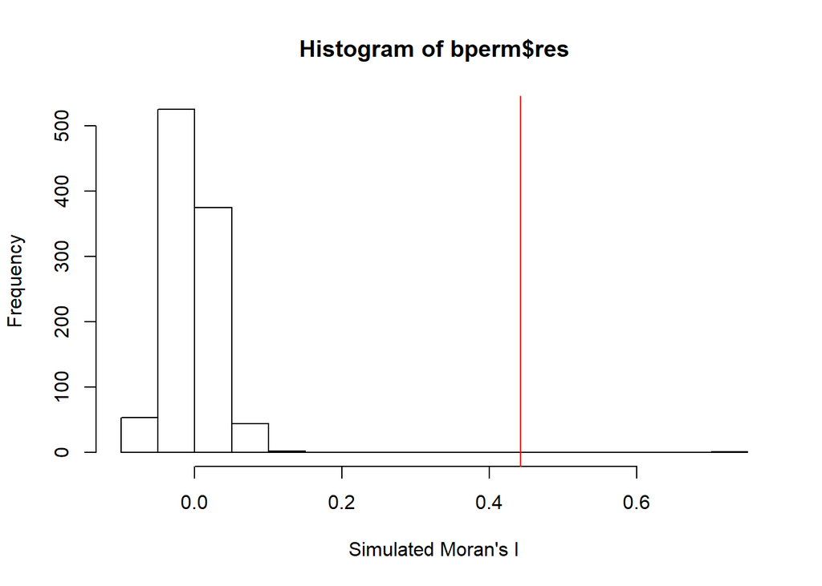

```r
bperm<-moran.mc(density,listw=TWN_nb_w,nsim=999, zero.policy=T)#做999次的排列檢定(拆開重新亂排排列)
hist(bperm$res, freq=TRUE, breaks=20, xlab="Simulated Moran's I")
abline(v=0.442, col="red")#顯示統計顯著，真實狀況不是亂排的
```

```r
#很顯著的正相關
```

#####moran.mc(density,listw=TWN_nb_w,nsim=999,zero.policy=T)中的nsim=999代表做999次的排列檢定(拆開重新亂排排列)。用蒙地卡羅作檢測，發現真實人口密度趨勢之於鄰近區域趨勢的I很明顯偏離隨機分布的狀況。

##Moran scatter plot

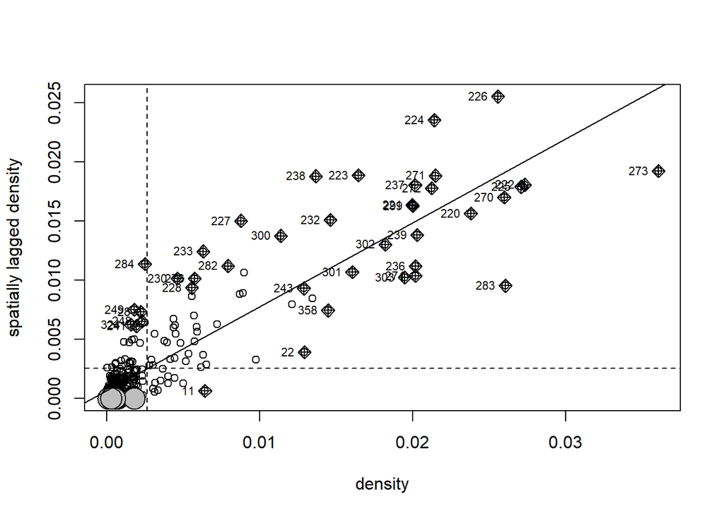

```r
moran.plot (density, TWN_nb_w, zero.policy=T)
```

##### moran.plot (density, TWN_nb_w, zero.policy=T)是以人口密度為主，以列標準化的方式加權所畫出的I數值散布圖。可以看到趨勢線主要通過一、三象限，代表人口密度與鄰近程度呈現正相關。

### Correlogram

```
## Spatial correlogram for density
## method: Moran's I
##             estimate expectation    variance standard deviate
## 1 (357)   0.70381652 -0.00280899  0.00107938          21.5081
## 2 (357)   0.37701617 -0.00280899  0.00061233          15.3494
## 3 (353)   0.14626861 -0.00284091  0.00039596           7.4934
## 4 (349)   0.02460139 -0.00287356  0.00025198           1.7308
## 5 (349)  -0.00634159 -0.00287356  0.00020052          -0.2449
## 6 (349)  -0.04681396 -0.00287356  0.00016801          -3.3900
## 7 (349)  -0.04513285 -0.00287356  0.00014538          -3.5048
## 8 (349)  -0.01006903 -0.00287356  0.00013443          -0.6206
## 9 (349)  -0.03484390 -0.00287356  0.00014026          -2.6995
## 10 (344) -0.12162522 -0.00291545  0.00016661          -9.1968
##          Pr(I) two sided
## 1 (357)        < 2.2e-16 ***
## 2 (357)        < 2.2e-16 ***
## 3 (353)         6.71e-14 ***
## 4 (349)        0.0834825 .
## 5 (349)        0.8065285
## 6 (349)        0.0006990 ***
## 7 (349)        0.0004569 ***
## 8 (349)        0.5348668
## 9 (349)        0.0069441 **
## 10 (344)       < 2.2e-16 ***
## ---
## Signif. codes:  0 '***' 0.001 '**' 0.01 '*' 0.05 '.' 0.1 ' ' 1
```

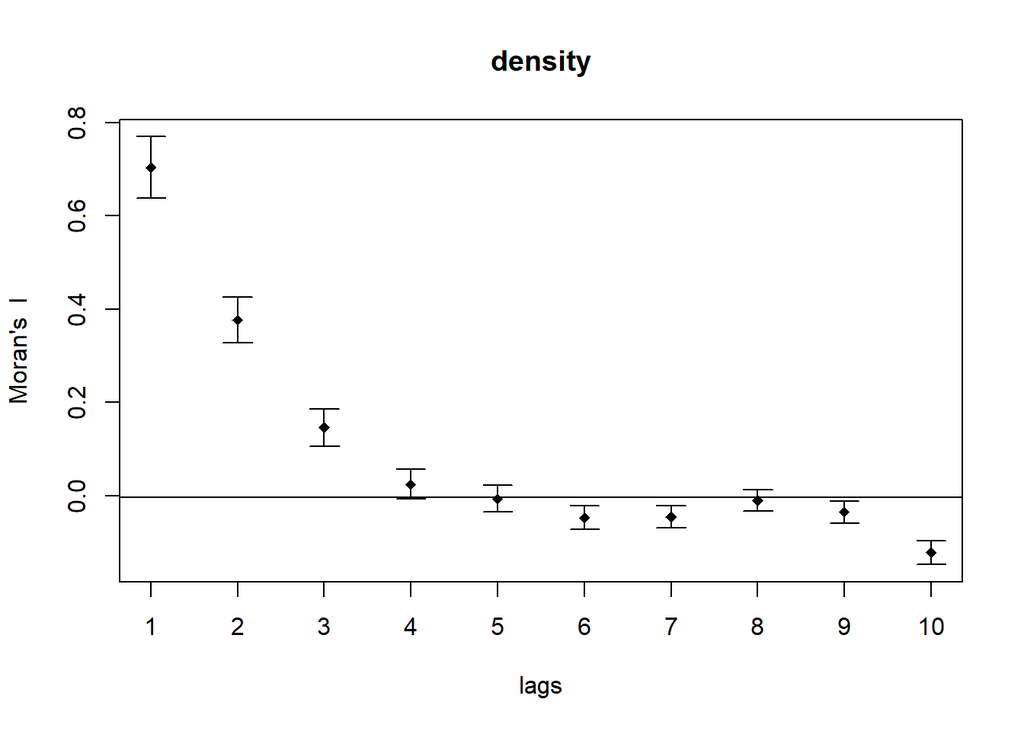

```r
cor<-sp.correlogram(TWN_nb, density, order=10, method="I", style="W",zero.policy=T)#第1,2,3階鄰居
print(cor); plot(cor)
```

#2.

###Moran’s I coefficient

```r
#相接相鄰
TWN_nb<-poly2nb(TWPOP) #QUEEN = TRUE，紀錄每個polygon的鄰居數
TWN_nb_w<- nb2listw(TWN_nb, zero.policy=T) # default: style = "W" #列標準化
density<-(TWTable$A0A14_CNT+TWTable$A15A64_CNT+TWTable$A65UP_CNT)/poly.areas(TWPOP)
density<-as.numeric(paste(density))
M<-moran.test(density, listw=TWN_nb_w, zero.policy=T); M  #人口資料，listw:空間權重，zero:如果有孤立點的話怎麼半
```

```
##
##  Moran I test under randomisation
##
## data:  density
## weights: TWN_nb_w  n reduced by no-neighbour observations
##
##
## Moran I statistic standard deviate = 21.508, p-value < 2.2e-16
## alternative hypothesis: greater
## sample estimates:
## Moran I statistic       Expectation          Variance
##       0.703816518      -0.002808989       0.001079383
```

### K

```r
IDs <-TWTable$TOWN_ID
coords<-coordinates(TWPOP)#產生polygon中心點座標
TWN_kn1<-knn2nb(knearneigh(coords, k=2), row.names=IDs)#找最近的兩個
TWN_kn1_w<- nb2listw(TWN_kn1, zero.policy=T) # default: style = "W" #列標準化
M_k<-moran.test(density, listw=TWN_kn1_w, zero.policy=T); M_k  #人口資料，listw:空間權重，zero:如果有孤立點的話怎麼半
```

```
##
##  Moran I test under randomisation
##
## data:  density
## weights: TWN_kn1_w
##
## Moran I statistic standard deviate = 19.303, p-value < 2.2e-16
## alternative hypothesis: greater
## sample estimates:
## Moran I statistic       Expectation          Variance
##       0.898830864      -0.002724796       0.002181314
```

### Distance-based

```r
TWN_ran1<-dnearneigh(coords, d1=0, d2=20000, row.names=IDs)#d1:中心點，d2:範圍
TWN_ran1_w<- nb2listw(TWN_ran1, zero.policy=T) # default: style = "W" #列標準化
M_d<-moran.test(density, listw=TWN_ran1_w, zero.policy=T); M_d  #人口資料，listw:空間權重，zero:如果有孤立點的話怎麼半
```

```
##
##  Moran I test under randomisation
##
## data:  density
## weights: TWN_ran1_w  n reduced by no-neighbour observations
##
##
## Moran I statistic standard deviate = 14.623, p-value < 2.2e-16
## alternative hypothesis: greater
## sample estimates:
## Moran I statistic       Expectation          Variance
##      0.3656213899     -0.0027700831      0.0006346913
```

##### 可以發現用k-order的方式會呈現出最大的正相關性，這也許是因為依照最近距離選取鄰近區域，在鄰近程度上是最高的，人口密度的集中與否會更為明顯；而用contiguity的方式挑選鄰居時，鄰近程度比k還要低，但比Distance-based要高，所以I分數是第二高。而Distance-based因為是限定範圍去篩選，可能選到邊界不相接的區域，意思是鄰近程度會更低，正相關程度也就是最低的。